# Phase Rule and Chemographic Diagrams

Dr. Ahmad Redaa

06-12-2025

# 1. What Is the Phase Rule in Metamorphic Systems?

The Gibbs Phase Rule is a fundamental thermodynamic equation that tells us how many variables (degrees of freedom) can change independently in a metamorphic system without altering the number of phases in equilibrium.

## 1.1 General Form of the Gibbs Phase Rule

$$F = C - P + 2$$

Where:  
- **F** = degrees of freedom (variance)  
- **C** = number of chemical components in the system  
- **P** = number of mineral phases in equilibrium

The phase rule tells us **how restrictive** equilibrium is in P–T space.

## 1.2 Why the Phase Rule Matters in Metamorphic Petrology

1. **Determines reaction types:**
   - Invariant (F=0)
   - Univariant (F=1)
   - Bivariant (F=2)
2. **Controls the number of stable minerals:**  
   Rocks do not contain more phases than allowed by the phase rule.
3. **Explains metamorphic reaction boundaries:**  
   More variance → larger stability fields.
4. **Controls mineral assemblage changes:**  
   Helps predict which reactions occur as P–T conditions evolve.

## 1.3 Simplified Phase Rule for Geological Systems

For most metamorphic systems with **fixed pressure and temperature** as variables:

$$F = C - P + 2$$

If a **fluid phase** is present but has fixed composition (e.g. pure H$_2$O), then:

- The fluid phase counts as a **mineral phase**
- But the composition does *not* add a new component

If a **variable fluid composition** exists (e.g., H$_2$O–CO$_2$ mixtures), then **C increases**, raising the variance (F).

## 1.4 Examples in Metamorphic Rocks

The following examples illustrate how the Gibbs Phase Rule is used to determine whether an assemblage is **invariant**, **univariant**, or **bivariant/multivariant** in metamorphic systems.

We use the simplified **MAS system**:

- **M**gO
- **A**l₂O₃
- **S**iO₂

So the number of components is:

$$C = 3$$

## Example 1: Five-Phase Assemblage

### Fo – Ky – Qz – Cd – Py in MAS

**Phases present (P = 5):**

- **Fo** = Forsterite (Mg₂SiO₄)
- **Ky** = Kyanite (Al₂SiO₅)
- **Qz** = Quartz (SiO₂)
- **Cd** = Cordierite (Mg₂Al₄Si₅O₁₈)
- **Py** = Pyrope (Mg₃Al₂Si₃O₁₂)

Apply the Gibbs Phase Rule:

$$F = C - P + 2 = 3 - 5 + 2 = 0$$

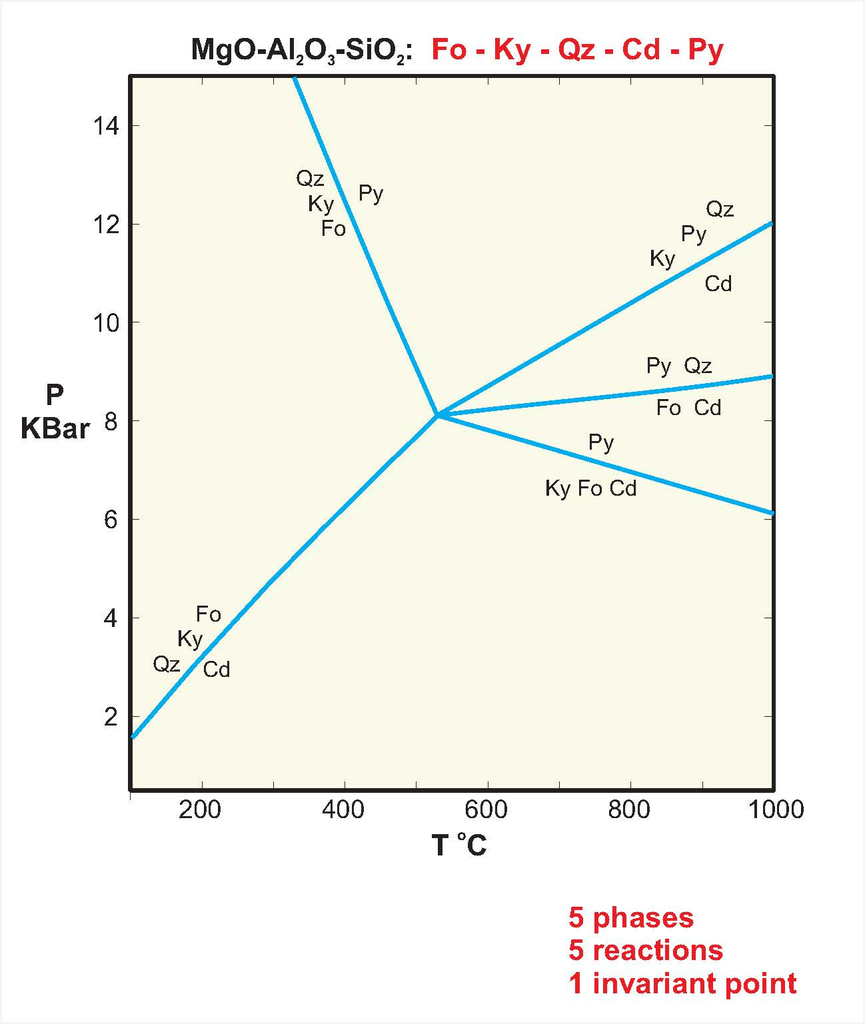

Source: [https://serc.carleton.edu](https://serc.carleton.edu/research_education/equilibria/metamorphic_diagrams.html)

## Example 2: Four-Phase Assemblage

### Fo – Ky – Qz – Cd in MAS

**Phases present (P = 4):**

- **Fo** = Forsterite
- **Ky** = Kyanite
- **Qz** = Quartz
- **Cd** = Cordierite

Apply the Gibbs Phase Rule:

$$F = C - P + 2 = 3 - 4 + 2 = 1$$

### **Interpretation**

- **F = 1 → Univariant assemblage**
- These four minerals coexist **along a line** in P–T space.
- The corresponding univariant reaction is:

$$\text{Fo} + \text{Ky} + \text{Qz} = \text{Cd}$$

This reaction appears as a **reaction curve** on a P–T diagram.

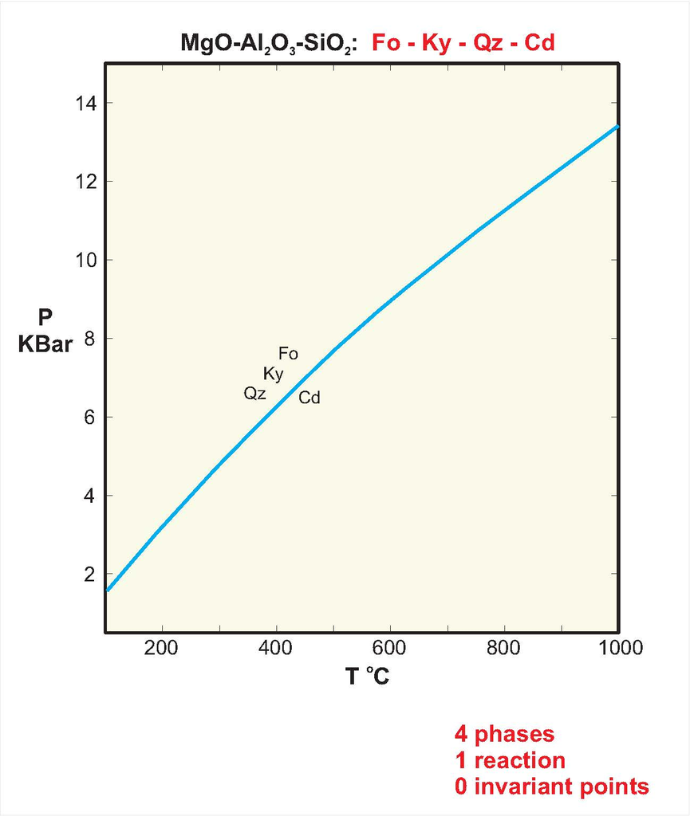

Source: [https://serc.carleton.edu](https://serc.carleton.edu/research_education/equilibria/metamorphic_diagrams.html)

# 2. What Is a Chemographic Diagram in Metamorphic Systems?

- A **chemographic diagram** is a graphical tool used to represent **mineral compositions and phase relations** in a simplified chemical system.
- Because real rocks have many components, chemographic diagrams reduce the system to 2–4 key components to make mineral relationships easier to visualise.

## 2.1 Purpose of Chemographic Diagrams

Chemographic diagrams are used to:

- Display stable and possible mineral assemblages
- Visualise reaction relationships
- Simplify complex mineral chemistry
- Show compatibility and incompatibility among minerals
- Illustrate compositional tie-lines between coexisting phases

# 3. Types of Chemographic Diagrams

## 3.1 Binary Diagram (2-component system)

- A straight line from component A to component B
- Commonly used for **solid solutions** (e.g., olivine forsterite–fayalite)

Useful for:  
- Phase boundaries  
- Solid solution composition ranges  
- Two-phase fields

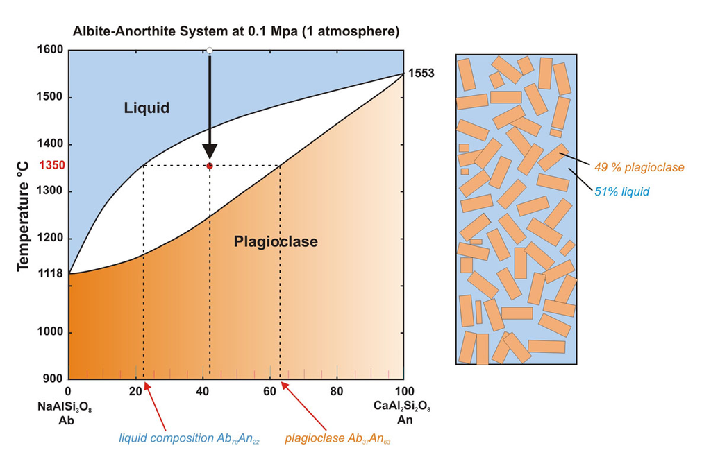

Source: [https://serc.carleton.edu](https://serc.carleton.edu/research_education/equilibria/binary_diagrams.html)

## 3.2 Ternary Diagram (3-component system)

The most widely used in metamorphic petrology.

### Examples

- **AFM diagram** (Al$_2$O$_3$–FeO–MgO) for metapelites
- **A–K–F diagram** (Al$_2$O$_3$–K$_2$O–FeO/MgO)
- **Na$_2$O–CaO–FeO+MgO diagram** for amphibolite facies rocks

Ternary diagrams help identify:  
- Possible mineral combinations  
- Tie-line relationships (minerals that coexist)  
- Reaction trends (e.g., garnet growth, biotite breakdown)

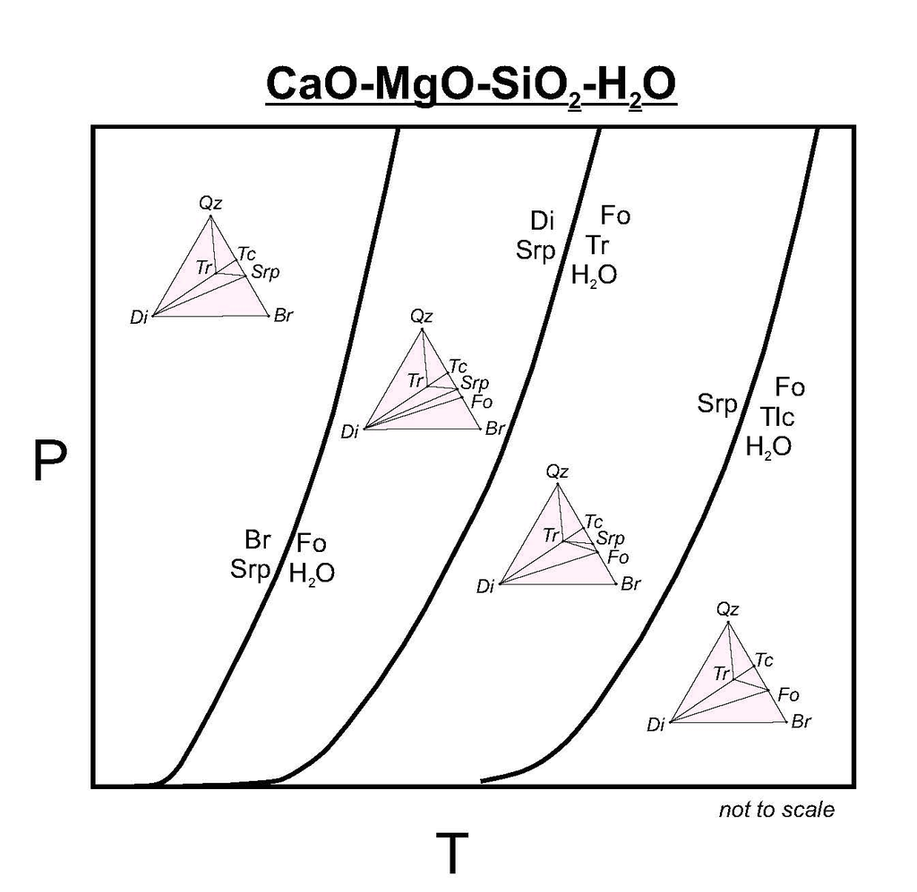

Source: [https://serc.carleton.edu](https://serc.carleton.edu/research_education/equilibria/binary_diagrams.html)

# 4. How Chemographic Diagrams Are Used

## 4.1 To determine coexisting mineral assemblages

- Minerals connected by **tie-lines** can coexist in equilibrium
- Minerals not connected by a tie-line **cannot** coexist

## 4.2 To identify metamorphic reactions

Changing P–T conditions may rotate or eliminate tie-lines, showing reactions such as:

- garnet + chlorite → biotite + staurolite
- muscovite breakdown into K-feldspar + sillimanite

## 4.3 To represent bulk-rock compositions

Bulk compositions plotted within the diagram show:

- which minerals should form
- how they evolve with P–T

## 4.4 To reduce system complexity

Real rocks have 8–12 major components.  
Chemographic diagrams simplify to 2–4 components so we can visualise phase relationships.

# 5. Key Differences: Phase Rule vs. Chemographic Diagram

| Concept | What It Describes | Purpose |
| --- | --- | --- |
| **Phase Rule** | Thermodynamic constraints (F, C, P) | Predict number of phases, reaction variance |
| **Chemographic Diagram** | Geometric relations among mineral compositions | Visualise mineral coexistence & reactions |

**Phase rule = mathematical constraints**  
**Chemographic diagrams = visual representation of mineral relationships**

They complement each other.

https://www.science.smith.edu/~jbrady/petrology/metrocks-activities/cmSerpentinite/cmSerpentinite-page07.php

More reading: https://opengeology.org/petrology/11-metamorphic-reactions/